# Self Regulation Ontology Retest Data: Initial Exploration

# Loading and matching datasets

### Load original data

```r
test_data <- read.csv('/Users/zeynepenkavi/Documents/PoldrackLabLocal/Self_Regulation_Ontology/Data/Complete_01-31-2017/variables_exhaustive.csv')
```

### Load retest data

```r
retest_data <- read.csv('/Users/zeynepenkavi/Documents/PoldrackLabLocal/Self_Regulation_Ontology/Data/Retest_02-11-2017/variables_exhaustive.csv')
```

Function to process lookup table

```r
process_lookup <- function(lookup_json){
  lookup_json <- data.frame(unlist(lookup_json))
  lookup_json$sub_id <- as.character(row.names(lookup_json))
  row.names(lookup_json) <- seq(1:nrow(lookup_json))
  names(lookup_json)[1] <- 'worker_id'
  lookup_json$worker_id <- as.character(lookup_json$worker_id)
  lookup_json$complete <- ifelse(lookup_json$worker_id == lookup_json$sub_id, 0, 1)
  lookup_json <- lookup_json %>% arrange(-complete, sub_id)
  return(lookup_json)
}
```

### Extract retest participants from test data

```r
test_worker_lookup <- fromJSON('/Users/zeynepenkavi/Documents/PoldrackLabLocal/Self_Regulation_Ontology/Data/Retest_02-11-2017/Local/worker_lookup.json')

#Process full lookup tables for both datasets
test_worker_lookup <- process_lookup(test_worker_lookup)

#Process sub_id columns in the data dataframes
retest_data$X <- as.character(retest_data$X)
test_data$X <- as.character(test_data$X)

names(retest_data)[1] <- 'sub_id'
names(test_data)[1] <- 'sub_id'

#Trim lookup table to only include those we have data for
test_worker_lookup <- test_worker_lookup[test_worker_lookup$sub_id %in% test_data$sub_id,]

#Replace worker_id's in retest_data with original sub_id's
correct_subids <- function(row, lookup_table){
  sub_id = row$sub_id
  if(sub_id %in% lookup_table$worker_id){
    index = which(sub_id == lookup_table$worker_id)
    sub_id = lookup_table$sub_id[index]
    row$sub_id = sub_id
  }
  return(row)
}

retest_data <- retest_data %>%
  group_by(sub_id) %>%
  do(correct_subids(.,test_worker_lookup))
```

### Checks and matching issues

Are all retest subjects in test_data? No.

```r
sum(retest_data$sub_id %in% test_data$sub_id) == nrow(retest_data)
```

```
[1] FALSE
```

Who is missing?

```r
retest_data$sub_id[which(retest_data$sub_id %in% test_data$sub_id == FALSE)]
```

```
[1] "s442"
```

```
s442
```

One retest participant is not in test data. Remove that subject from retest_data. This participant should not have completed the retest battery to begin with because they had failed our previous criterion on number of properly completed trials. The first HIT I posted, however, had an issue with the qualifications and before I could terminate it a handful of subjects had accepted and begun the battery so we had to let them finish. So this subject has given us good data for the retest battery but worse data for the test battery.

```r
retest_data <- retest_data[retest_data$sub_id %in% test_data$sub_id,]

retest_data
```

| sub_id | adaptive_n_back.EZ_drift | adaptive_n_back.EZ_non_decision | adaptive_n_back.EZ_thresh | adaptive_n_back.acc | adaptive_n_back.avg_rt | adaptive_n_back.avg_rt_error | adaptive_n_back.hddm_drift | adaptive_n_back.hddm_non_decision | adaptive_n_back.hddm_thresh | adaptive_n_back.mean_load | adaptive_n_back.missed_percent | adaptive_n_back.post_error_slowing | adaptive_n_back.std_rt | adaptive_n_back.std_rt_error | angling_risk_task_always_sunny.keep_adjusted_clicks | angling_risk_task_always_sunny.keep_loss_percent | angling_risk_task_always_sunny.keep_score | angling_risk_task_always_sunny.release_adjusted_clicks | angling_risk_task_always_sunny.release_loss_percent | angling_risk_task_always_sunny.release_score | attention_network_task.EZ_drift | attention_network_task.EZ_drift_congruent | attention_network_task.EZ_drift_incongruent | attention_network_task.EZ_drift_neutral | attention_network_task.EZ_non_decision | attention_network_task.EZ_non_decision_congruent | attention_network_task.EZ_non_decision_incongruent | attention_network_task.EZ_non_decision_neutral | attention_network_task.EZ_thresh | … |
| --- | --- | --- | --- | --- | --- | --- | --- | --- | --- | --- | --- | --- | --- | --- | --- | --- | --- | --- | --- | --- | --- | --- | --- | --- | --- | --- | --- | --- | --- | --- |
| s286 | 0.9070 | 0.39498 | 1.0995 | 0.7995 | 611.0 | 670.0 | 0.7262 | 0.15956 | 1.611 | 1.700 | 0.000000 | 81.3235 | 211.25 | 235.41 | NA | NA | NA | NA | NA | NA | 3.328 | 2.889 | 3.512 | 3.666 | 0.5780 | 0.5402 | 0.6043 | 0.6117 | 1.2787 | … |
| s502 | 0.9103 | 0.38700 | 1.1033 | 0.7930 | 630.0 | 594.0 | 0.7736 | 0.21757 | 1.409 | 1.750 | 0.011494 | 0.4889 | 214.22 | 240.04 | 32.250 | 0.06667 | 876 | 16.7308 | 0.13333 | 410 | 3.554 | 3.889 | 2.985 | 3.817 | 0.4395 | 0.4221 | 0.4864 | 0.4428 | 1.1955 | … |
| s507 | 1.5357 | 0.50459 | 1.1719 | 0.8151 | 757.0 | 741.0 | 1.3048 | 0.33867 | 1.605 | 2.650 | 0.033113 | 27.0952 | 225.67 | 254.60 | NA | NA | NA | NA | NA | NA | 2.973 | 3.766 | 2.728 | 2.965 | 0.4704 | 0.4664 | 0.5226 | 0.4496 | 1.1184 | … |
| s173 | 4.2924 | 0.30734 | 0.8762 | 0.8417 | 375.0 | 406.0 | 2.3458 | 0.19410 | 1.416 | 4.050 | 0.002079 | 30.5429 | 110.63 | 110.63 | NA | NA | NA | NA | NA | NA | 2.825 | 3.772 | 2.792 | 2.515 | 0.3279 | 0.3557 | 0.4214 | 0.2393 | 1.2584 | … |
| s062 | 1.4221 | 0.54096 | 1.0209 | 0.8038 | 750.0 | 816.0 | 1.0634 | 0.30079 | 1.612 | 2.100 | 0.042986 | 23.4054 | 189.38 | 211.84 | 22.400 | 0.16667 | 535 | 25.5455 | 0.26667 | 534 | 3.417 | 3.267 | 3.205 | 3.391 | 0.4891 | 0.4702 | 0.5637 | 0.4831 | 1.4484 | … |
| s334 | NA | NA | NA | NA | NA | NA | NA | NA | NA | NA | NA | NA | NA | NA | 29.091 | 0.26667 | 610 | 26.5652 | 0.23333 | 580 | 2.616 | 3.491 | 2.004 | 2.963 | 0.4662 | 0.4330 | 0.5589 | 0.4263 | 1.1988 | … |
| s005 | 1.7162 | 0.32141 | 0.8799 | 0.8310 | 470.0 | 505.0 | 1.5112 | 0.25700 | 1.115 | 1.900 | 0.013699 | 32.1429 | 118.02 | 89.10 | 23.269 | 0.13333 | 580 | 22.2222 | 0.40000 | 375 | 3.267 | 3.658 | 3.031 | 3.116 | 0.4196 | 0.4066 | 0.4922 | 0.3913 | 1.3047 | … |
| s007 | 1.0473 | 0.38597 | 1.0759 | 0.7836 | 599.5 | 616.0 | 0.9261 | 0.26997 | 1.390 | 1.950 | 0.000000 | 18.0652 | 197.91 | 281.82 | 30.864 | 0.26667 | 643 | 35.9524 | 0.30000 | 700 | 3.877 | 3.992 | 4.077 | 3.509 | 0.5281 | 0.5253 | 0.6276 | 0.4887 | 1.2801 | … |
| s009 | 1.5095 | 0.29024 | 1.0819 | 0.8200 | 443.0 | 458.0 | 1.2559 | 0.13272 | 1.574 | 2.550 | 0.002217 | 14.0690 | 161.87 | 213.24 | 48.182 | 0.26667 | 1010 | 30.5556 | 0.40000 | 520 | 3.940 | 3.777 | 3.778 | 4.531 | 0.3712 | 0.3768 | 0.3945 | 0.3606 | 0.9773 | … |
| s011 | 2.2678 | 0.35471 | 1.0797 | 0.8341 | 502.0 | 518.0 | 1.8136 | 0.19087 | 1.652 | 3.000 | 0.004348 | 45.2708 | 181.78 | 226.60 | 24.304 | 0.23333 | 538 | 15.7692 | 0.13333 | 394 | 2.569 | 2.770 | 3.151 | 2.192 | 0.3707 | 0.3173 | 0.5061 | 0.3158 | 1.3725 | … |

[output cut: 137 more lines]

Extract test data for retest subjects

```r
retest_subs_test_data <- test_data[test_data$sub_id %in% retest_data$sub_id,]

rest_subs_test_data <- test_data[test_data$sub_id %in% retest_data$sub_id == FALSE,]

#Arrange datasets of same size by sub_id
retest_data = retest_data %>% arrange(sub_id)
retest_subs_test_data = retest_subs_test_data %>% arrange(sub_id)

#CHECK IF EVERYTHING IS ORDERED RIGHT
retest_subs_test_data$sub_id == retest_data$sub_id
```

```
  [1] TRUE TRUE TRUE TRUE TRUE TRUE TRUE TRUE TRUE TRUE TRUE TRUE TRUE TRUE
 [15] TRUE TRUE TRUE TRUE TRUE TRUE TRUE TRUE TRUE TRUE TRUE TRUE TRUE TRUE
 [29] TRUE TRUE TRUE TRUE TRUE TRUE TRUE TRUE TRUE TRUE TRUE TRUE TRUE TRUE
 [43] TRUE TRUE TRUE TRUE TRUE TRUE TRUE TRUE TRUE TRUE TRUE TRUE TRUE TRUE
 [57] TRUE TRUE TRUE TRUE TRUE TRUE TRUE TRUE TRUE TRUE TRUE TRUE TRUE TRUE
 [71] TRUE TRUE TRUE TRUE TRUE TRUE TRUE TRUE TRUE TRUE TRUE TRUE TRUE TRUE
 [85] TRUE TRUE TRUE TRUE TRUE TRUE TRUE TRUE TRUE TRUE TRUE TRUE TRUE TRUE
 [99] TRUE TRUE TRUE TRUE TRUE TRUE TRUE TRUE TRUE TRUE TRUE TRUE TRUE TRUE
[113] TRUE TRUE TRUE TRUE TRUE TRUE TRUE TRUE TRUE TRUE TRUE TRUE TRUE TRUE
[127] TRUE TRUE TRUE TRUE TRUE TRUE TRUE TRUE TRUE TRUE TRUE TRUE TRUE TRUE
[141] TRUE TRUE TRUE TRUE TRUE TRUE TRUE
```

Drop columns from original data that are not in retest data

Are there any columns in retest data columns that are not in the original data: No.

```r
names(retest_data)[names(retest_data) %in% names(retest_subs_test_data) == FALSE]
```

```
character(0)
```

Test data columns that are not in the retest data: Two stage hasn’t been fixed yet.

```r
names(retest_subs_test_data)[names(retest_subs_test_data) %in% names(retest_data) == FALSE]
```

```
[1] "two_stage_decision.perseverance"
```

```
two_stage_decision.perseverance
```

Datasets with only matching columns

```r
all_columns <- unique(c(names(retest_data), names(retest_subs_test_data)))

matching_columns <- c()
for(i in 1:length(all_columns)){
  if(all_columns[i] %in% names(retest_data) & all_columns[i] %in% names(retest_subs_test_data)){
    matching_columns <- c(matching_columns, all_columns[i])
  }
}

retest_data <- retest_data[,matching_columns]
retest_subs_test_data <- retest_subs_test_data[,matching_columns]
```

# Correlations of exhaustive variables

Get list of test retest correlations for all matching (numeric) columns in the test and retest data. Note two caveats:  
**1. There are still some columns that weren’t in both datasets listed above (e.g. two stage)**  
**2. Unlike meaningful variables these variables are not (yet) rid of outliers or log transformed if skewed. This will be detailed below along with its problems.**

```r
retest_data <- as.data.frame(retest_data)
retest_subs_test_data <- as.data.frame(retest_subs_test_data)

matching_dv_columns <- c()

for(i in 1:length(matching_columns)){
  if(is.numeric(retest_data[,matching_columns[i]]) & is.numeric(retest_subs_test_data[,matching_columns[i]])){
    matching_dv_columns <- c(matching_dv_columns, matching_columns[i])
  }
}

cor_df <- data.frame(pearson = rep(NA, length(matching_dv_columns)), spearman = rep(NA, length(matching_dv_columns)))

row.names(cor_df) <- matching_dv_columns

for(i in 1:length(matching_dv_columns)){
  cor_df[matching_dv_columns[i], 'pearson'] <- cor(retest_data[,matching_dv_columns[i]], retest_subs_test_data[,matching_dv_columns[i]], method = 'pearson', use = "pairwise.complete.obs")
  cor_df[matching_dv_columns[i], 'spearman'] <- cor(retest_data[,matching_dv_columns[i]],retest_subs_test_data[,matching_dv_columns[i]], method = 'spearman', use = "pairwise.complete.obs")
}
```

Distribution of all Pearson and Spearman correlations

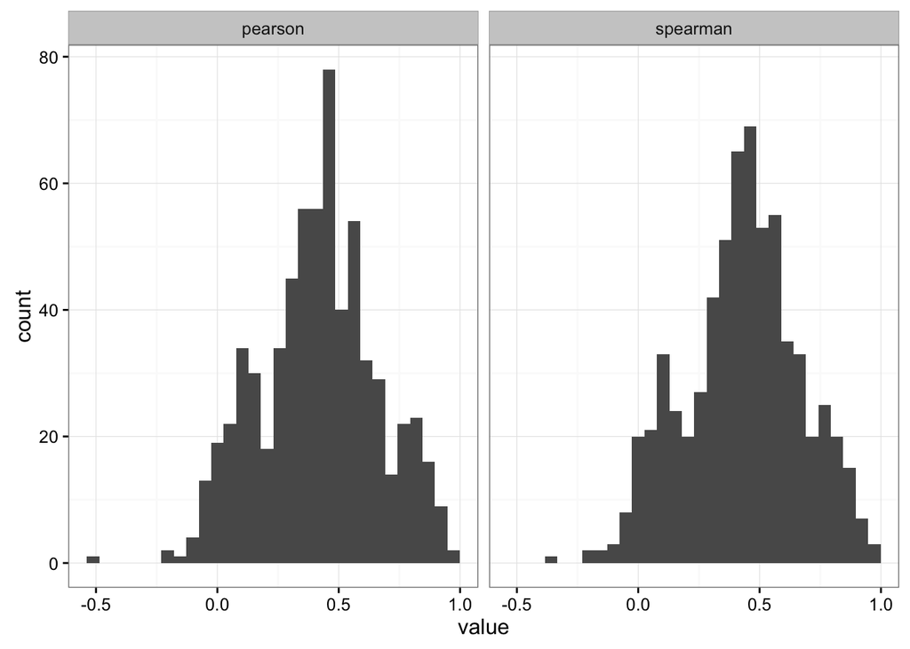

```r
cor_df %>%
  gather(key, value) %>%
  ggplot(aes(value))+
  geom_histogram()+
  theme_bw()+
  facet_wrap(~key)
```

Add column to tasks vs. surveys in correlation table

```r
cor_df$dv = row.names(cor_df)
row.names(cor_df) = seq(1:nrow(cor_df))
cor_df$task = 'task'
cor_df[grep('survey', cor_df$dv), 'task'] = 'survey'
```

## Distributions of correlations by task vs. survey

Survey reliabilities are noticably higher than task reliabilities.

Task reliability distributions looks alsmost bimodal. **Should figure out whether the lower ones are specific tasks or if they are certain kinds of vars (e.g. certain ddm parameters)**

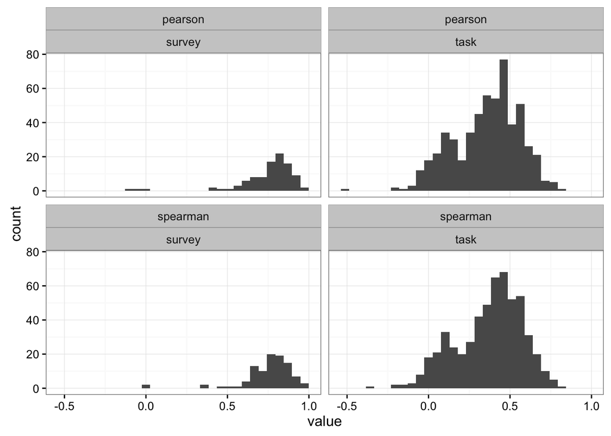

```r
cor_df %>%
  gather(key, value, -dv, -task) %>%
  ggplot(aes(value))+
  geom_histogram()+
  theme_bw()+
  facet_wrap(key~task)
```

Mean reliability and the number of variables for both the surveys and the tasks

```r
cor_df %>%
  group_by(task) %>%
  summarise(mean_pearson = mean(pearson),
            mean_spearman = mean(spearman),
            num_vars = n())
```

| task | mean_pearson | mean_spearman | num_vars |
| --- | --- | --- | --- |
| survey | 0.7472 | 0.7542 | 98 |
| task | 0.3566 | 0.3737 | 556 |

### Rank order of correlations

#### For tasks

```r
cor_df %>%
  filter(task == 'task') %>%
  select(dv, spearman, pearson) %>%
  arrange(-pearson, -spearman)
```

| dv | spearman | pearson |
| --- | --- | --- |
| adaptive_n_back.mean_load | 0.743475 | 8.167e-01 |
| kirby.percent_patient | 0.797721 | 7.873e-01 |
| ravens.score | 0.783004 | 7.793e-01 |
| kirby.hyp_discount_rate | 0.778326 | 7.464e-01 |
| kirby.percent_patient_large | 0.747677 | 7.453e-01 |
| adaptive_n_back.avg_rt | 0.717112 | 7.424e-01 |
| adaptive_n_back.avg_rt_error | 0.702558 | 7.416e-01 |
| kirby.percent_patient_small | 0.718599 | 7.257e-01 |
| kirby.percent_patient_medium | 0.731065 | 7.166e-01 |
| information_sampling_task.Fixed_Win_motivation | 0.704799 | 7.115e-01 |

[output cut: 546 more lines]

#### For surveys

Note: Holt and Laury test-retest is pretty terrible. In previous data I have worked with it was ~.35. Should check to see if there is a coding error there.

```r
cor_df %>%
  filter(task == 'survey') %>%
  select(dv, spearman, pearson) %>%
  arrange(-pearson, -spearman)
```

| dv | spearman | pearson |
| --- | --- | --- |
| demographics_survey.age | 0.996276 | 0.99672 |
| demographics_survey.household_income.dollars. | 0.957284 | 0.97771 |
| demographics_survey.arrest_count | 0.828550 | 0.91993 |
| ten_item_personality_survey.extraversion | 0.913042 | 0.91719 |
| demographics_survey.relationship_count | 0.908897 | 0.91294 |
| ten_item_personality_survey.emotional_stability | 0.882007 | 0.90965 |
| bis_bas_survey.BIS | 0.896750 | 0.90863 |
| demographics_survey.weight.pounds. | 0.935806 | 0.90628 |
| demographics_survey.education | 0.892615 | 0.90603 |
| demographics_survey.children_count | 0.970005 | 0.90547 |

[output cut: 88 more lines]

## Distribution of each variable

The smaller meaningful_vars dataframe has been somewhat cleaned. So far in this notebook we looked at all the vars in their rawest form. Here we’ll first check the distributions of all the variables and then apply the same cleaning procedure that was used for the meaningful variables to all of them.

Note that I’m doing this for the sake of consistency for now. We might later decide that we would like to transform certain variables of interest in other ways to be able to include them in our analyses without violating the assumptions of those analyses. The current procedure checks the skewness of a column first removes the outliers defined as greater than 2.5 IQR from median then variables with skewness >1 are log transformed.

First I’ll check if the variables that went in to the correlation matrix have normal distributions since at least the Pearson correlations depend on this assumption. Then everything will be cleaned the way meaningful variables was cleaned. There is a problem with this approach that I’m not sure how to deal with yet but this will be detailed below.

Function to check if the variables that went in to cor_df have normal distributions

```r
diff_from_normal <- function(col){
  return(shapiro.test(col)$p.value < 0.05)
}
```

Create and organize new df where distribution of vars data is stored. First for retest data only; then for test data for subjects who have retest data - restricting here since these are the subsets of data that went in to the correlation matrix. Merge and cleanup.

```r
dist_retest_data <- as.data.frame(apply(retest_data[,matching_dv_columns], 2, diff_from_normal))
names(dist_retest_data) <- c('retest_not_normal')
dist_retest_data$dv <- row.names(dist_retest_data)
row.names(dist_retest_data) <- seq(1:nrow(dist_retest_data))
dist_retest_data = dist_retest_data %>% select(dv, retest_not_normal)

dist_retest_subs_test_data <- as.data.frame(apply(retest_subs_test_data[,matching_dv_columns], 2, diff_from_normal))
names(dist_retest_subs_test_data) <- c('test_not_normal')
dist_retest_subs_test_data$dv <- row.names(dist_retest_subs_test_data)
row.names(dist_retest_subs_test_data) <- seq(1:nrow(dist_retest_subs_test_data))
dist_retest_subs_test_data = dist_retest_subs_test_data %>% select(dv, test_not_normal)

dist_data <- merge(dist_retest_data, dist_retest_subs_test_data, by = 'dv')

rm(dist_retest_data, dist_retest_subs_test_data)
```

Add whether dv’s are tasks or survey to distribution dfs

```r
dist_data = cor_df %>%
  select(dv, task) %>%
  left_join(dist_data, by = 'dv')
```

**What proportion is not normal?**  
A large proportion of the variables are not normal for data from both sources. Larger proportions of survey data are not normal compared to task data.

```r
dist_data %>%
  group_by(task) %>%
  summarise(mean_retest_not_normal  = mean(retest_not_normal),
            mean_test_not_normal = mean(test_not_normal))
```

| task | mean_retest_not_normal | mean_test_not_normal |
| --- | --- | --- |
| survey | 0.8469 | 0.8776 |
| task | 0.6942 | 0.6817 |

**Are the same vars that are not normally distributed in the retest data not normal in test data as well?**  
List of variables that have different distributions in the two time points. A majority of them are drift diffusion parameters (but note that these vars are overrepresented to begin with - more on them later).

```r
dist_data %>%
  filter(retest_not_normal != test_not_normal)
```

| dv | task | retest_not_normal | test_not_normal |
| --- | --- | --- | --- |
| angling_risk_task_always_sunny.keep_adjusted_clicks | task | TRUE | FALSE |
| angling_risk_task_always_sunny.keep_score | task | TRUE | FALSE |
| angling_risk_task_always_sunny.release_score | task | TRUE | FALSE |
| attention_network_task.EZ_drift | task | FALSE | TRUE |
| attention_network_task.EZ_drift_congruent | task | FALSE | TRUE |
| attention_network_task.EZ_drift_incongruent | task | FALSE | TRUE |
| attention_network_task.EZ_drift_neutral | task | FALSE | TRUE |
| attention_network_task.EZ_non_decision | task | TRUE | FALSE |
| attention_network_task.EZ_non_decision_congruent | task | TRUE | FALSE |
| attention_network_task.EZ_non_decision_neutral | task | TRUE | FALSE |

[output cut: 128 more lines]

Apply the same cleaning procedure that was used for meaningful vars for all vars:

```r
remove_outliers = function(data_column, quantile_range = 2.5){

  q_25 = quantile(data_column, na.rm=T)[2]
  q_50 = quantile(data_column, na.rm=T)[3]
  q_75 = quantile(data_column, na.rm=T)[4]

  lowlimit = q_50 - quantile_range*(q_75 - q_25)
  highlimit = q_50 + quantile_range*(q_75 - q_25)

  data_column = ifelse(data_column<lowlimit, NA, ifelse(data_column>highlimit, NA, data_column))

  return(data_column)
}

"%w/o%" <- function(x, y) x[!x %in% y]

neg_log <- function(column){
  col_max = max(column, na.rm=T)
  column = col_max+1-column
  return(log(column))
}

transform_remove_skew = function(data, columns, threshold = 1){

  tmp = as.data.frame(apply(data[,columns],2,skew))
  names(tmp) = c("skew")
  tmp$dv = row.names(tmp)
  tmp = tmp %>%
    filter(abs(skew)>threshold)

  skewed_variables = tmp$dv
  skew_subset = data[, skewed_variables]
  positive_subset = data[,tmp$dv[tmp$skew>0]]
  negative_subset = data[,tmp$dv[tmp$skew<0]]

  # transform variables
  # log transform for positive skew
  positive_subset = log(positive_subset)
  successful_transforms = as.data.frame(apply(positive_subset, 2, skew))
  names(successful_transforms) = c('skew')
  successful_transforms$dv = row.names(successful_transforms)
  successful_transforms = successful_transforms %>% filter(abs(skew)<threshold)
  successful_transforms = successful_transforms$dv
  successful_transforms = positive_subset[,successful_transforms]
  dropped_vars = names(positive_subset) %w/o% names(successful_transforms)

  # replace transformed variables
  data = data[,-c(which(names(data) %in% names(positive_subset)))]
  names(successful_transforms) = paste0(names(successful_transforms), '.logTr')
  cat(rep('*', 40))
  cat('\n')
  cat(paste0('Dropping ', length(dropped_vars) ,' positively skewed data that could not be transformed successfully:'))
  cat('\n')
  cat(dropped_vars, sep = '\n')
  cat(rep('*', 40))
  cat('\n')
  data = cbind(data, successful_transforms)

  # reflected log transform for negative skew
  negative_subset = as.data.frame(apply(negative_subset, 2, neg_log))
  successful_transforms = as.data.frame(apply(negative_subset, 2, skew))
  names(successful_transforms) = c('skew')
  successful_transforms$dv = row.names(successful_transforms)
  successful_transforms = successful_transforms %>% filter(abs(skew)<1)
  successful_transforms = successful_transforms$dv
  successful_transforms = negative_subset[,successful_transforms]
  dropped_vars = names(negative_subset) %w/o% names(successful_transforms)

  # replace transformed variables
  data = data[,-c(which(names(data) %in% names(negative_subset)))]
  names(successful_transforms) = paste0(names(successful_transforms), '.ReflogTr')
  cat(rep('*', 40))
  cat('\n')
  cat(paste0('Dropping ', length(dropped_vars) ,' negatively skewed data that could not be transformed successfully:'))
  cat('\n')
  cat(dropped_vars, sep = '\n')
  cat(rep('*', 40))
  cat('\n')
  data = cbind(data, successful_transforms)

  return(data)
}
```

Clean retest data with these rules.

```r
clean_retest_data = as.data.frame(apply(retest_data[, matching_dv_columns], 2, remove_outliers))
clean_retest_data = transform_remove_skew(clean_retest_data, matching_dv_columns)
```

```
* * * * * * * * * * * * * * * * * * * * * * * * * * * * * * * * * * * * * * * *
Dropping 18 positively skewed data that could not be transformed successfully:
adaptive_n_back.missed_percent
attention_network_task.missed_percent
bickel_titrator.hyp_discount_rate_small
demographics_survey.caffeine_intake
demographics_survey.car_debt
demographics_survey.mortage_debt
directed_forgetting.missed_percent
dot_pattern_expectancy.missed_percent
hierarchical_rule.missed_percent
impulsive_venture_survey.impulsiveness
local_global_letter.missed_percent
probabilistic_selection.missed_percent
psychological_refractory_period_two_choices.missed_percent
shape_matching.missed_percent
shift_task.missed_percent
stroop.missed_percent
threebytwo.missed_percent
two_stage_decision.missed_percent
* * * * * * * * * * * * * * * * * * * * * * * * * * * * * * * * * * * * * * * *
* * * * * * * * * * * * * * * * * * * * * * * * * * * * * * * * * * * * * * * *
Dropping 7 negatively skewed data that could not be transformed successfully:
attention_network_task.acc
choice_reaction_time.acc
directed_forgetting.acc
go_nogo.go_acc
motor_selective_stop_signal.stop_acc
psychological_refractory_period_two_choices.task1_acc
psychological_refractory_period_two_choices.task2_acc
* * * * * * * * * * * * * * * * * * * * * * * * * * * * * * * * * * * * * * * *
```

**I’m not sure what the right thing to do is regarding the cleaning of the test data for the retest subjects.**  
Should they be cleaned on the whole sample for the time they were collected on and then extracted (this should have an effect on outliers as well as transformations) or extracted and then cleaned. Here I am doing the latter but this seems to be resulting in more skewed variables for test data compared to the retest data so the later correlation matrix might not include all the variables we would like to look at.

```r
clean_retest_subs_test_data = as.data.frame(apply(retest_subs_test_data[, matching_dv_columns], 2, remove_outliers))
clean_retest_subs_test_data = transform_remove_skew(clean_retest_subs_test_data, matching_dv_columns)
```

```
* * * * * * * * * * * * * * * * * * * * * * * * * * * * * * * * * * * * * * * *
Dropping 20 positively skewed data that could not be transformed successfully:
adaptive_n_back.missed_percent
attention_network_task.missed_percent
attention_network_task.std_rt_error
bickel_titrator.hyp_discount_rate_small
demographics_survey.car_debt
demographics_survey.mortage_debt
demographics_survey.other_sources_of_debt
dickman_survey.dysfunctional
directed_forgetting.missed_percent
dot_pattern_expectancy.missed_percent
hierarchical_rule.missed_percent
impulsive_venture_survey.impulsiveness
local_global_letter.missed_percent
probabilistic_selection.missed_percent
psychological_refractory_period_two_choices.missed_percent
shape_matching.missed_percent
shift_task.missed_percent
stroop.missed_percent
threebytwo.missed_percent
two_stage_decision.missed_percent
* * * * * * * * * * * * * * * * * * * * * * * * * * * * * * * * * * * * * * * *
* * * * * * * * * * * * * * * * * * * * * * * * * * * * * * * * * * * * * * * *
Dropping 9 negatively skewed data that could not be transformed successfully:
attention_network_task.acc
directed_forgetting.acc
go_nogo.go_acc
information_sampling_task.Fixed_Win_acc
motor_selective_stop_signal.stop_acc
psychological_refractory_period_two_choices.task1_acc
psychological_refractory_period_two_choices.task2_acc
shape_matching.acc
stim_selective_stop_signal.go_acc
* * * * * * * * * * * * * * * * * * * * * * * * * * * * * * * * * * * * * * * *
```

## Correlations on cleaned variables

Create the same list of correlations as before but this time on a smaller set of cleaned variables.

```r
clean_all_columns <- unique(c(names(clean_retest_data), names(clean_retest_subs_test_data)))

clean_matching_columns <- c()
for(i in 1:length(clean_all_columns)){
  if(clean_all_columns[i] %in% names(clean_retest_data) & clean_all_columns[i] %in% names(clean_retest_subs_test_data)){
    clean_matching_columns <- c(clean_matching_columns, clean_all_columns[i])
  }
}

# clean_retest_data <- clean_retest_data[,clean_matching_columns]
# clean_retest_subs_test_data <- clean_retest_subs_test_data[,clean_matching_columns]

clean_matching_dv_columns <- c()

for(i in 1:length(clean_matching_columns)){
  if(is.numeric(clean_retest_data[,clean_matching_columns[i]]) & is.numeric(clean_retest_subs_test_data[,clean_matching_columns[i]])){
    clean_matching_dv_columns <- c(clean_matching_dv_columns, clean_matching_columns[i])
  }
}

clean_cor_df <- data.frame(pearson = rep(NA, length(clean_matching_dv_columns)), spearman = rep(NA, length(clean_matching_dv_columns)))

row.names(clean_cor_df) <- clean_matching_dv_columns

for(i in 1:length(clean_matching_dv_columns)){

  robustCor <- function(...) {
    obj<-try(cor(...), silent=TRUE)
    if (is(obj, "try-error")) return(NA) else return(obj)
  }

  tmp_pearson = robustCor(clean_retest_data[,clean_matching_dv_columns[i]], clean_retest_subs_test_data[,clean_matching_dv_columns[i]], method = 'pearson', use = "pairwise.complete.obs")

  tmp_spearman = robustCor(clean_retest_data[,clean_matching_dv_columns[i]], clean_retest_subs_test_data[,clean_matching_dv_columns[i]], method = 'spearman', use = "pairwise.complete.obs")

  clean_cor_df[clean_matching_dv_columns[i], 'pearson'] <- tmp_pearson
  clean_cor_df[clean_matching_dv_columns[i], 'spearman'] <- tmp_spearman

}

clean_cor_df$dv = row.names(clean_cor_df)
row.names(clean_cor_df) = seq(1:nrow(clean_cor_df))
clean_cor_df$task = 'task'
clean_cor_df[grep('survey', clean_cor_df$dv), 'task'] = 'survey'
```

Correlations could not be calculated for the following variables due to lack of variance.

```r
clean_cor_df %>%
  filter(is.na(pearson)) %>%
  select(dv)
```

| dv |
| --- |
| choice_reaction_time.missed_percent |
| demographics_survey.arrest_count |
| demographics_survey.divoce_count |
| demographics_survey.traffic_ticket_count |
| holt_laury_survey.number_of_switches |
| recent_probes.missed_percent |
| simon.missed_percent |
| simple_reaction_time.missed_percent |

Let’s look at the distributions again: The distributions don’t look terribly different but there are noticably fewer variables post cleaning.

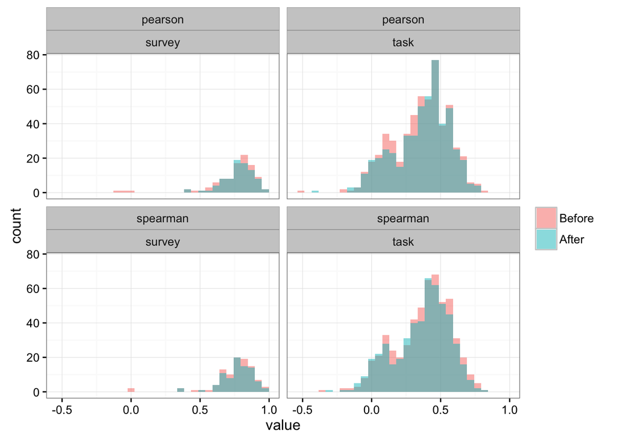

```r
cor_df %>%
  left_join(clean_cor_df, by='dv') %>%
  select(-task.y)%>%
  rename(pearson_preClean = pearson.x, spearman_preClean = spearman.x,
         pearson_postClean = pearson.y, spearman_postClean = spearman.y,
         task = task.x) %>%
  gather(key, value, -dv, -task) %>%
  separate(key, c('cor_type', 'clean_type'),sep = "_") %>%
  ggplot(aes(x=value, fill=factor(clean_type, levels = c('preClean', 'postClean'),
                                  labels = c('Before', 'After'))))+
  geom_histogram(position='identity', alpha = 0.5)+
  facet_wrap(cor_type~task)+
  theme_bw()+
  theme(legend.title = element_blank())
```

This cleaning led to a slight change in the mean reliabilities but a lot of dropped variables.

```r
clean_cor_df %>%
  group_by(task) %>%
  summarise(mean_pearson = mean(pearson, na.rm=T),
            mean_spearman = mean(spearman, na.rm=T),
            num_vars = sum(ifelse(is.na(pearson)==FALSE,1,0)))
```

| task | mean_pearson | mean_spearman | num_vars |
| --- | --- | --- | --- |
| survey | 0.7784 | 0.7766 | 85 |
| task | 0.3664 | 0.3673 | 521 |

**What changed most with cleaning?**  
Difference in correlation pre and post correlation for the variables that survived cleaning.  
Things that changed most seem to be RTs and parameter estimates.

```r
clean_cor_df %>%
  left_join(cor_df, by='dv') %>%
  mutate(pearson_diff = abs(pearson.y - pearson.x),
         spearman_diff = abs(spearman.y - spearman.x)) %>%
  select(dv, pearson_diff, spearman_diff) %>%
  arrange(-pearson_diff, -spearman_diff)
```

| dv | pearson_diff | spearman_diff |
| --- | --- | --- |
| discount_titrate.hyp_discount_rate_nm | 0.3966708 | 2.519e-02 |
| discount_titrate.hyp_discount_rate_glm_now | 0.3713337 | 8.918e-02 |
| attention_network_task.conflict_acc | 0.3105677 | 1.449e-02 |
| motor_selective_stop_signal.hddm_non_decision | 0.3016063 | 6.495e-02 |
| adaptive_n_back.std_rt | 0.2847434 | 4.354e-03 |
| adaptive_n_back.EZ_non_decision | 0.2671688 | 1.812e-02 |
| stim_selective_stop_signal.EZ_non_decision | 0.2666847 | 1.601e-02 |
| stop_signal.go_rt_error | 0.2599601 | 1.530e-01 |
| stroop.stroop_acc | 0.2491337 | 7.589e-02 |
| directed_forgetting.post_error_slowing | 0.2484660 | 1.183e-01 |

[output cut: 604 more lines]

# Different task variable types

Mean reliabilities for different types of dependant variables

## Drift diffusion variables: raw vars vs. EZ vs. hddm

We should probably take a closer look at model fits instead but this could be a first step.  
I’m not sure why there are so many more EZ variables than hddm variables.

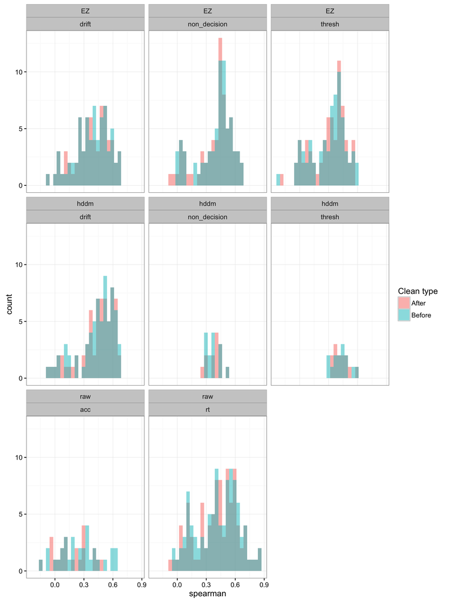

```r
cor_df%>%
  select(-pearson) %>%
  filter(grepl('EZ|hddm|_rt|_acc', dv)) %>%
  mutate(var_type = ifelse(grepl('EZ',dv), 'EZ', ifelse(grepl('hddm',dv), 'hddm', 'raw')),
         var = ifelse(grepl('_rt', dv), 'rt', ifelse(grepl('_acc', dv), 'acc', ifelse(grepl('_non_decision', dv), 'non_decision', ifelse(grepl('_thresh', dv), 'thresh', ifelse(grepl('_drift', dv), 'drift', NA)))))) %>%
  left_join(clean_cor_df[,c('spearman', 'dv')], by = 'dv') %>%
  gather(clean_type, spearman, -dv, -var_type, -var, -task) %>%
  mutate(clean_type = ifelse(clean_type == 'spearman.x','Before','After')) %>%
  ggplot(aes(spearman, fill = clean_type))+
  geom_histogram(position='identity', alpha = 0.5)+
  theme_bw()+
  facet_wrap(var_type~var)+
  scale_fill_discrete(name = 'Clean type')
```

Average reliabilities

```r
cor_df%>%
  select(-pearson) %>%
  filter(grepl('EZ|hddm|_rt|_acc', dv)) %>%
  mutate(var_type = ifelse(grepl('EZ',dv), 'EZ', ifelse(grepl('hddm',dv), 'hddm', 'raw')),
         var = ifelse(grepl('_rt', dv), 'rt', ifelse(grepl('_acc', dv), 'acc', ifelse(grepl('_non_decision', dv), 'non_decision', ifelse(grepl('_thresh', dv), 'thresh', ifelse(grepl('_drift', dv), 'drift', NA)))))) %>%
  left_join(clean_cor_df[,c('spearman', 'dv')], by = 'dv') %>%
  gather(clean_type, spearman, -dv, -var_type, -var, -task) %>%
  mutate(clean_type = ifelse(clean_type == 'spearman.x','Before','After')) %>%
  group_by(var_type, clean_type, var) %>%
  summarise(mean_spearman = mean(spearman, na.rm=T),
            sem_spear = sem(spearman),
            num_vars = sum(ifelse(is.na(spearman)==FALSE,1,0))) %>%
  arrange(var_type, -as.numeric(as.factor(clean_type)))
```

| var_type | clean_type | var | mean_spearman | sem_spear | num_vars |
| --- | --- | --- | --- | --- | --- |
| EZ | Before | drift | 0.3813 | 0.02138 | 69 |
| EZ | Before | non_decision | 0.3967 | 0.02209 | 69 |
| EZ | Before | thresh | 0.3008 | 0.02189 | 69 |
| EZ | After | drift | 0.3745 | 0.02157 | 69 |
| EZ | After | non_decision | 0.3898 | 0.02247 | 69 |
| EZ | After | thresh | 0.2962 | 0.02143 | 69 |
| hddm | Before | drift | 0.4337 | 0.02262 | 68 |
| hddm | Before | non_decision | 0.3680 | 0.01856 | 14 |
| hddm | Before | thresh | 0.4269 | 0.02230 | 14 |
| hddm | After | drift | 0.4285 | 0.02282 | 68 |

[output cut: 6 more lines]

## Other variable types

I planned to look at differences between distributions of reliabilities for other variables types as well but I am not sure what these categories should be so I am deferring this for further discussions. My earlier notes suggested differences between other model parameters versus raw variables; subtraction versus basic variables; single versus multiple variables.I’m hoping we can come up with a more systematic definition that I can automatize or at least restrict to certain groups of variable instead of going through all 600+ variables and manually labeling them.

# Replicating the factor structure

## Confirm comparability of retest and rest sample

First do a t-test on all measures of T1 for subjects with and without retest to confirm that these two samples do not differ from each other significantly

```r
ttest_df = data.frame(t_stat = rep(NA, length(matching_dv_columns)),
                      p_val = rep(NA, length(matching_dv_columns)))

row.names(ttest_df) <- matching_dv_columns

for(i in 1:length(matching_dv_columns)){
  ttest_df[matching_dv_columns[i], 't_stat'] <- t.test(retest_subs_test_data[,matching_dv_columns[i]], rest_subs_test_data[,matching_dv_columns[i]])$statistic

  ttest_df[matching_dv_columns[i], 'p_val'] <- t.test(retest_subs_test_data[,matching_dv_columns[i]], rest_subs_test_data[,matching_dv_columns[i]])$p.value
}

ttest_df$dv = row.names(ttest_df)
row.names(ttest_df) = seq(1:nrow(ttest_df))
ttest_df$task = 'task'
ttest_df[grep('survey', ttest_df$dv), 'task'] = 'survey'
```

Distribution of t values

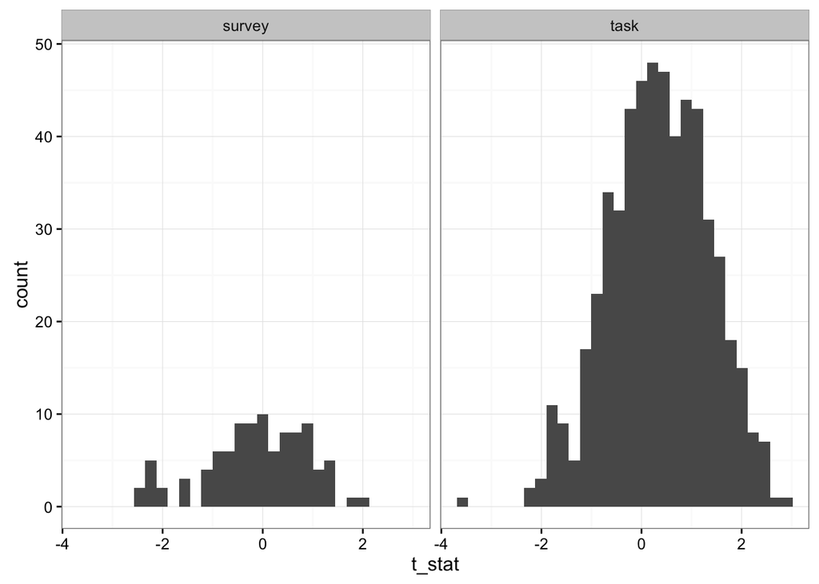

```r
ttest_df %>%
  ggplot(aes(t_stat)) +
  geom_histogram()+
  theme_bw()+
  facet_wrap(~task)
```

**Which variables are significantly different between the two samples (those with and without retest data for T1)?**

43 variables. None of them are very strongly different though.

```r
ttest_df %>%
  filter(p_val<0.05) %>%
  select(dv, task, t_stat, p_val)
```

| dv | task | t_stat | p_val |
| --- | --- | --- | --- |
| angling_risk_task_always_sunny.keep_adjusted_clicks | task | 2.048 | 0.0415901 |
| angling_risk_task_always_sunny.keep_score | task | 2.330 | 0.0205467 |
| attention_network_task.alerting_acc | task | 2.618 | 0.0093424 |
| bickel_titrator.hyp_discount_rate_large | task | -2.153 | 0.0318710 |
| columbia_card_task_hot.information_use | task | 2.036 | 0.0427717 |
| demographics_survey.education | survey | 2.111 | 0.0357559 |
| dickman_survey.dysfunctional | survey | -2.345 | 0.0195883 |
| dickman_survey.functional | survey | -2.148 | 0.0326389 |
| directed_forgetting.EZ_thresh | task | 2.127 | 0.0343973 |
| directed_forgetting.EZ_thresh_pos | task | 2.331 | 0.0205588 |

[output cut: 33 more lines]

Do this again with cleaned data.  
Clean the T1 data for the subsets first.  
**Here again I’m not sure if I should clean before or after splitting. Before it seemed appropriate to clean subjects with retest data after separating them from the remaining subjects but here it might be better to clean first and then separate. But then it would differ from what was done for earlier anaylses and it seems like the kind of thing that should be kept consistent.**

Clean T1 for subjects with retest data (doing it again because this df was subsetted before)

```r
clean_retest_subs_test_data = as.data.frame(apply(retest_subs_test_data[, matching_dv_columns], 2, remove_outliers))
clean_retest_subs_test_data = transform_remove_skew(clean_retest_subs_test_data, matching_dv_columns)
```

```
* * * * * * * * * * * * * * * * * * * * * * * * * * * * * * * * * * * * * * * *
Dropping 20 positively skewed data that could not be transformed successfully:
adaptive_n_back.missed_percent
attention_network_task.missed_percent
attention_network_task.std_rt_error
bickel_titrator.hyp_discount_rate_small
demographics_survey.car_debt
demographics_survey.mortage_debt
demographics_survey.other_sources_of_debt
dickman_survey.dysfunctional
directed_forgetting.missed_percent
dot_pattern_expectancy.missed_percent
hierarchical_rule.missed_percent
impulsive_venture_survey.impulsiveness
local_global_letter.missed_percent
probabilistic_selection.missed_percent
psychological_refractory_period_two_choices.missed_percent
shape_matching.missed_percent
shift_task.missed_percent
stroop.missed_percent
threebytwo.missed_percent
two_stage_decision.missed_percent
* * * * * * * * * * * * * * * * * * * * * * * * * * * * * * * * * * * * * * * *
* * * * * * * * * * * * * * * * * * * * * * * * * * * * * * * * * * * * * * * *
Dropping 9 negatively skewed data that could not be transformed successfully:
attention_network_task.acc
directed_forgetting.acc
go_nogo.go_acc
information_sampling_task.Fixed_Win_acc
motor_selective_stop_signal.stop_acc
psychological_refractory_period_two_choices.task1_acc
psychological_refractory_period_two_choices.task2_acc
shape_matching.acc
stim_selective_stop_signal.go_acc
* * * * * * * * * * * * * * * * * * * * * * * * * * * * * * * * * * * * * * * *
```

Clean T1 for rest of the subjects

```r
clean_rest_subs_test_data = as.data.frame(apply(rest_subs_test_data[, matching_dv_columns], 2, remove_outliers))
clean_rest_subs_test_data = transform_remove_skew(clean_rest_subs_test_data, matching_dv_columns)
```

```
* * * * * * * * * * * * * * * * * * * * * * * * * * * * * * * * * * * * * * * *
Dropping 21 positively skewed data that could not be transformed successfully:
adaptive_n_back.missed_percent
attention_network_task.missed_percent
bickel_titrator.hyp_discount_rate_small
choice_reaction_time.std_rt_error
demographics_survey.car_debt
demographics_survey.children_count
demographics_survey.longest_relationship.months.
demographics_survey.mortage_debt
dickman_survey.dysfunctional
directed_forgetting.missed_percent
dot_pattern_expectancy.missed_percent
hierarchical_rule.missed_percent
impulsive_venture_survey.impulsiveness
local_global_letter.missed_percent
probabilistic_selection.missed_percent
psychological_refractory_period_two_choices.missed_percent
shape_matching.missed_percent
shift_task.missed_percent
stroop.missed_percent
threebytwo.missed_percent
two_stage_decision.missed_percent
* * * * * * * * * * * * * * * * * * * * * * * * * * * * * * * * * * * * * * * *
* * * * * * * * * * * * * * * * * * * * * * * * * * * * * * * * * * * * * * * *
Dropping 8 negatively skewed data that could not be transformed successfully:
choice_reaction_time.acc
directed_forgetting.acc
dot_pattern_expectancy.acc
go_nogo.go_acc
motor_selective_stop_signal.stop_acc
psychological_refractory_period_two_choices.task1_acc
psychological_refractory_period_two_choices.task2_acc
stim_selective_stop_signal.go_acc
* * * * * * * * * * * * * * * * * * * * * * * * * * * * * * * * * * * * * * * *
```

Get numeric dv’s from both cleaned datasets to compute t-tests on.

```r
clean_all_columns <- unique(c(names(clean_rest_subs_test_data), names(clean_retest_subs_test_data)))

clean_matching_columns <- c()
for(i in 1:length(clean_all_columns)){
  if(clean_all_columns[i] %in% names(clean_rest_subs_test_data) & clean_all_columns[i] %in% names(clean_retest_subs_test_data)){
    clean_matching_columns <- c(clean_matching_columns, clean_all_columns[i])
  }
}

clean_matching_dv_columns <- c()

for(i in 1:length(clean_matching_columns)){
  if(is.numeric(clean_rest_subs_test_data[,clean_matching_columns[i]]) & is.numeric(clean_rest_subs_test_data[,clean_matching_columns[i]])){
    clean_matching_dv_columns <- c(clean_matching_dv_columns, clean_matching_columns[i])
  }
}
```

Compute t-tests for cleaned variables.

```r
clean_ttest_df = data.frame(t_stat = rep(NA, length(clean_matching_dv_columns)),
                      p_val = rep(NA, length(clean_matching_dv_columns)))

row.names(clean_ttest_df) <- clean_matching_dv_columns

for(i in 1:length(clean_matching_dv_columns)){

  robustTTest <- function(...) {
    obj<-try(t.test(...), silent=TRUE)
    if (is(obj, "try-error")) return(obj = data.frame(statistic = NA, p.value=NA)) else return(obj)
  }

  tmp = robustTTest(clean_retest_subs_test_data[,clean_matching_dv_columns[i]], clean_rest_subs_test_data[,clean_matching_dv_columns[i]])

  clean_ttest_df[clean_matching_dv_columns[i], 't_stat'] <- tmp$statistic
  clean_ttest_df[clean_matching_dv_columns[i], 'p_val'] <- tmp$p.value
    }

clean_ttest_df$dv = row.names(clean_ttest_df)
row.names(clean_ttest_df) = seq(1:nrow(clean_ttest_df))
clean_ttest_df$task = 'task'
clean_ttest_df[grep('survey', clean_ttest_df$dv), 'task'] = 'survey'
```

Variables for which t-tests cannot be computed due to lack of variance.

```r
clean_ttest_df %>%
  filter(is.na(t_stat)) %>%
  select(dv)
```

| dv |
| --- |
| choice_reaction_time.missed_percent |
| demographics_survey.arrest_count |
| demographics_survey.divoce_count |
| demographics_survey.traffic_ticket_count |
| holt_laury_survey.number_of_switches |
| recent_probes.missed_percent |
| simon.missed_percent |
| simple_reaction_time.missed_percent |

Distribution of t-tests for the cleaned variables with sufficient variance

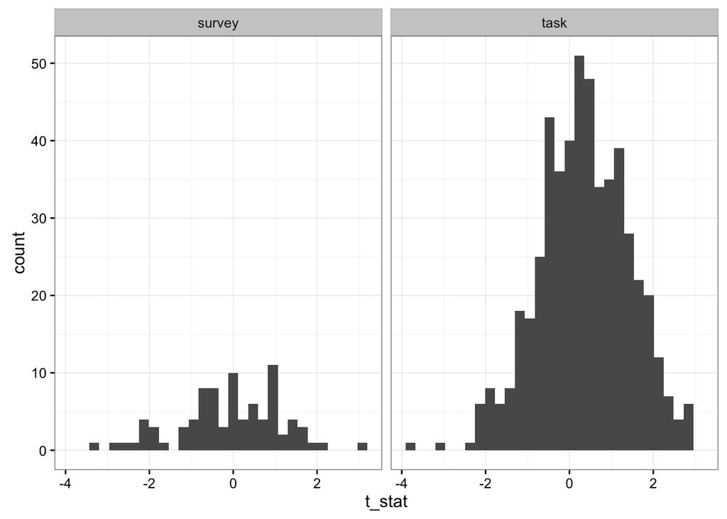

```r
clean_ttest_df %>%
  filter(!is.na(t_stat)) %>%
ggplot(aes(t_stat)) +
  geom_histogram()+
  theme_bw()+
  facet_wrap(~task)
```

**Which variables are significantly different between the two samples on cleaned data (those with and without retest data for T1)?**

More variables (that are thought to have been properly cleaned for these analyses) are significantly different between the two samples.  
**Not sure what to do with this especially for the next set of analyses.**

```r
clean_ttest_df %>%
  filter(!is.na(p_val) & p_val<0.05) %>%
  select(dv, task, t_stat, p_val)
```

| dv | task | t_stat | p_val |
| --- | --- | --- | --- |
| adaptive_n_back.EZ_non_decision | task | 1.996 | 0.0471602 |
| angling_risk_task_always_sunny.keep_adjusted_clicks | task | 2.048 | 0.0415901 |
| angling_risk_task_always_sunny.keep_score | task | 2.618 | 0.0093401 |
| attention_network_task.EZ_drift_incongruent | task | 1.986 | 0.0481239 |
| attention_network_task.EZ_thresh_neutral | task | -2.183 | 0.0298221 |
| bis11_survey.first_order_motor | survey | -2.000 | 0.0465052 |
| columbia_card_task_hot.information_use | task | 2.036 | 0.0427717 |
| demographics_survey.BMI | survey | 2.056 | 0.0408408 |
| demographics_survey.education | survey | 2.977 | 0.0032068 |
| dickman_survey.functional | survey | -2.148 | 0.0326389 |

[output cut: 47 more lines]

## Efa and Cfa

Step 2: Efa on the people you don’t have retest on and then predict how well this holds up for people w retest on t1 and on t2.

I’m restricting the factor analyses to the meaningful variables for now (instead of the 600+ exhaustive variables) to keep it manageable. I haven’t consulted other factor analyses that have been done on the full dataset in doing this but will be happy to adjust as necessary.

Data cleaning for efa

```r
#read in only meaningful vars
meaningful_var_test <- read.csv('/Users/zeynepenkavi/Documents/PoldrackLabLocal/Self_Regulation_Ontology/Data/Complete_01-31-2017/meaningful_variables_clean.csv')

meaningful_var_retest <- read.csv('/Users/zeynepenkavi/Documents/PoldrackLabLocal/Self_Regulation_Ontology/Data/Retest_02-11-2017/meaningful_variables_clean.csv')

#Process sub_id columns in the data dataframes
meaningful_var_retest$X <- as.character(meaningful_var_retest$X)
meaningful_var_test$X <- as.character(meaningful_var_test$X)

names(meaningful_var_retest)[1] <- 'sub_id'
names(meaningful_var_test)[1] <- 'sub_id'

#Clean and subset dfs as before
meaningful_var_retest <- meaningful_var_retest %>%
  group_by(sub_id) %>%
  do(correct_subids(.,test_worker_lookup))

#Remove sub w missing test data from retest data
retest_data_mngf <- meaningful_var_retest[meaningful_var_retest$sub_id %in% meaningful_var_test$sub_id,]

#Extract test data for subs w retest data
retest_subs_test_mngf <- meaningful_var_test[meaningful_var_test$sub_id %in% meaningful_var_retest$sub_id,]

#Extract test data for subs without retest data (efa df)
rest_subs_test_mngf <- meaningful_var_test[meaningful_var_test$sub_id %in% meaningful_var_retest$sub_id == FALSE,]

#Arrange datasets of same size by sub_id
retest_data_mngf = retest_data_mngf %>% arrange(sub_id)
retest_subs_test_mngf = retest_subs_test_mngf %>% arrange(sub_id)

#CHECK IF EVERYTHING IS ORDERED RIGHT
retest_subs_test_mngf$sub_id == retest_data_mngf$sub_id
```

```r
#Check columns
names(retest_data_mngf)[names(retest_data_mngf) %in% names(retest_subs_test_mngf) == FALSE]

names(retest_subs_test_mngf)[names(retest_subs_test_mngf) %in% names(retest_data_mngf) == FALSE]
```

[output not shown]

For now I’m just removing these variables but will have to do re-do them once I resolve why they weren’t in both datasets to begin with (The answer will be a combination of not having run the most recent analysis script on some tasks and dropped variables as a result of cleaning)

```r
#Subset datasets with only matching columns
all_columns_mngf <- unique(c(names(retest_data_mngf), names(retest_subs_test_mngf)))

matching_columns_mngf <- c()
for(i in 1:length(all_columns_mngf)){
  if(all_columns_mngf[i] %in% names(retest_data_mngf) & all_columns_mngf[i] %in% names(retest_subs_test_mngf)){
    matching_columns_mngf <- c(matching_columns_mngf, all_columns_mngf[i])
  }
}

retest_data_mngf <- retest_data_mngf[,matching_columns_mngf]
retest_subs_test_mngf <- retest_subs_test_mngf[,matching_columns_mngf]
rest_subs_test_mngf <- rest_subs_test_mngf[,matching_columns_mngf]

#standardize all vars going in to factor analysis
rest_subs_test_mngf_z <- rest_subs_test_mngf

for(i in 1:length(rest_subs_test_mngf)){
  if(names(rest_subs_test_mngf)[i] == 'sub_id'){
    rest_subs_test_mngf_z$sub_id = rest_subs_test_mngf$sub_id
  }
  else{
    rest_subs_test_mngf_z[,names(rest_subs_test_mngf)[i]] = scale(rest_subs_test_mngf[,i])
  }
}

rest_subs_test_mngf_z <- as.data.frame(rest_subs_test_mngf_z)
```

Efa on subjects from original dataset withOUT retest data (using meaningful vars only)

Trying to use `lavaan` first. It’s not happy with me.

```r
unrotated <- try(efaUnrotate(rest_subs_test_mngf_z, nf=3, varList=names(rest_subs_test_mngf_z)[-1], estimator="mlr"))
```

```
Warning in lav_data_full(data = data, group = group, group.label = group.label, : lavaan WARNING: small number of observations (nobs < nvar)
  nobs = 33 nvar = 182
```

```r
# summary(unrotated, std=TRUE)
# inspect(unrotated, "std")
```

Using the `psych` package I get some sort of solution but these are probably not valid given all the warnings.

```r
corMat <- rest_subs_test_mngf_z %>% select(-sub_id) %>% cor(.,use = 'complete.obs')

solution <- fa(r = corMat, nfactors = 3, rotate = "oblimin", fm = "pa")
```

```
Warning in cor.smooth(R): Matrix was not positive definite, smoothing was
done
```

```
Warning in cor.smooth(r): Matrix was not positive definite, smoothing was
done
```

```
The determinant of the smoothed correlation was zero.
This means the objective function is not defined.
Chi square is based upon observed residuals.
```

```
The determinant of the smoothed correlation was zero.
This means the objective function is not defined for the null model either.
The Chi square is thus based upon observed correlations.
```

```
The estimated weights for the factor scores are probably incorrect.  Try a different factor extraction method.
```

```
In factor.scores, the correlation matrix is singular, an approximation is used
```

```r
print(solution$loadings, sort=T)
```

```
Loadings:
                                                                PA1
bis_bas_survey.BAS_drive                                         0.541
bis_bas_survey.BAS_fun_seeking                                   0.643
bis_bas_survey.BIS                                              -0.568
choice_reaction_time.hddm_drift                                 -0.509
dospert_rt_survey.financial                                      0.696
dospert_rt_survey.recreational                                   0.645
dot_pattern_expectancy.hddm_drift                               -0.608
holt_laury_survey.safe_choices                                  -0.707
impulsive_venture_survey.venturesomeness                         0.676
information_sampling_task.Decreasing_Win_motivation              0.512
sensation_seeking_survey.disinhibition                           0.507
sensation_seeking_survey.thrill_adventure_seeking                0.619
ten_item_personality_survey.emotional_stability                  0.539
ten_item_personality_survey.extraversion                         0.560
threebytwo.cue_switch_cost_hddm_drift_100.0                      0.501
time_perspective_survey.present_hedonistic                       0.655
upps_impulsivity_survey.sensation_seeking                        0.815
bis11_survey.Attentional
bis11_survey.Nonplanning
brief_self_control_survey.self_control
dospert_rp_survey.health_safety                                 -0.183
dot_pattern_expectancy.hddm_non_decision                        -0.276
five_facet_mindfulness_survey.act_with_awareness
grit_scale_survey.grit
mindful_attention_awareness_survey.mindfulness
selection_optimization_compensation_survey.compensation
selection_optimization_compensation_survey.elective_selection
selection_optimization_compensation_survey.loss_based_selection -0.172
self_regulation_survey.control                                   0.204
ten_item_personality_survey.conscientiousness                    0.203
time_perspective_survey.future
time_perspective_survey.past_positive
time_perspective_survey.present_fatalistic                       0.125
upps_impulsivity_survey.lack_of_perseverance
upps_impulsivity_survey.lack_of_premeditation                    0.346
upps_impulsivity_survey.negative_urgency                         0.318
attention_network_task.conflict_hddm_drift                       0.111
attention_network_task.hddm_thresh
```

[output cut: 500 more lines]

```
time_perspective_survey.past_negative
tower_of_london.avg_move_time                                    0.364
tower_of_london.num_extra_moves                                 -0.274
tower_of_london.num_optimal_solutions
tower_of_london.planning_time                                    0.354
two_stage_decision.model_based
two_stage_decision.model_free                                   -0.217
upps_impulsivity_survey.positive_urgency                         0.128
writing_task.neutral_probability                                -0.121
writing_task.positive_probability

                  PA1    PA2    PA3
SS loadings    15.649 15.627 11.979
Proportion Var  0.086  0.086  0.066
Cumulative Var  0.086  0.172  0.238
```

# Invited vs. completed retest

T1 comparison for people who came back vs didn’t (of all that are invited)